# threat exploration

### Simple Slopes

```r
bfi_targ_comp_simpslopes_int_stereo <- emtrends(bfi_targ_comp_stereo, ~ itt_comp_gmc*target_condition,
                              var = "bfi_self_pmc",
                              at = list(target_condition = c("CONTROL",
                                                             "LOSS",
                                                             "WARM"),
                                        itt_comp_gmc = c(-1.07, 0.0, 1.07)))

bfi_targ_comp_simpslopes_int_stereo
```

```
##  itt_comp_gmc target_condition bfi_self_pmc.trend     SE  df asymp.LCL
##         -1.07 CONTROL                     0.17073 0.0225 Inf    0.1266
##          0.00 CONTROL                     0.17381 0.0359 Inf    0.1035
##          1.07 CONTROL                     0.17689 0.0626 Inf    0.0541
##         -1.07 LOSS                        0.08485 0.0667 Inf   -0.0458
##          0.00 LOSS                        0.01287 0.0349 Inf   -0.0555
##          1.07 LOSS                       -0.05912 0.0269 Inf   -0.1118
##         -1.07 WARM                        0.17624 0.0482 Inf    0.0818
##          0.00 WARM                        0.09230 0.0258 Inf    0.0418
##          1.07 WARM                        0.00835 0.0288 Inf   -0.0481
##  asymp.UCL
##    0.21485
##    0.24416
##    0.29968
##    0.21550
##    0.08120
##   -0.00643
##    0.27064
##    0.14284
##    0.06482
##
## Degrees-of-freedom method: asymptotic
## Confidence level used: 0.95
```

### Visualization

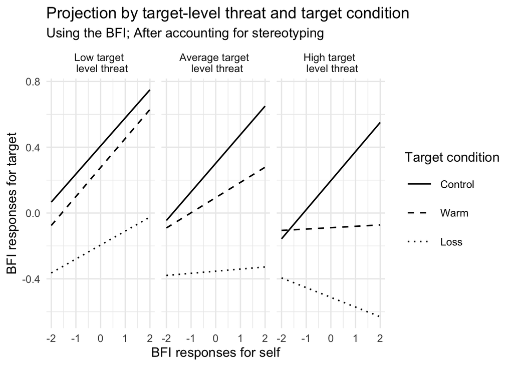

```r
bfi_targ_comp_int_viz_stereo <- effect("bfi_self_pmc:itt_comp_gmc:target_condition",
                         xlevels = list(itt_comp_gmc = c(-1.07, 0.0, 1.07),
                                        target_condition = c("CONTROL",
                                                             "WARM",
                                                             "LOSS")),
                         mod = bfi_targ_comp_stereo)

bfi_targ_comp_int_viz_stereo <- as.data.frame(bfi_targ_comp_int_viz_stereo)
bfi_targ_comp_int_viz_stereo$itt_comp_gmc <- as.factor(bfi_targ_comp_int_viz_stereo$itt_comp_gmc)
bfi_targ_comp_int_viz_stereo$target_condition <- as.factor(bfi_targ_comp_int_viz_stereo$target_condition)

threat_labels <- c("-1.07" = "Low target \n level threat",
                   "0" = "Average target \n level threat",
                   "1.07" = "High target \n level threat")

ggplot(bfi_targ_comp_int_viz_stereo, aes(bfi_self_pmc, fit, group = target_condition)) +
  geom_smooth(method = "lm",
                size = .7,
                se = FALSE,
                colour = "black",
                aes(linetype = target_condition)) +
    theme_minimal(base_size = 13) +
    theme(legend.key.size = unit(1, "cm")) +
  facet_wrap(~itt_comp_gmc,
             labeller = labeller(itt_comp_gmc = threat_labels)) +
  scale_linetype_manual("Target condition",
                        breaks = c("CONTROL", "WARM", "LOSS"),
                       labels = c("Control",
                                  "Warm",
                                  "Loss"),
                       values = c("solid",
                                  "dashed",
                                  "dotted")) +
    labs(title = "Projection by target-level threat and target condition",
         subtitle = "Using the BFI; After accounting for stereotyping",
       x = "BFI responses for self",
       y = "BFI responses for target")
```

## Distance

### Coffee alone

```r
bfi_coffee <- lmer(bfi_targ_pmc ~ bfi_self_pmc*distance_coffee +
                     (bfi_self_pmc | sub_id),
                   data = clean_data_bfi)

summary(bfi_coffee)
```

```
## Linear mixed model fit by REML ['lmerMod']
## Formula: bfi_targ_pmc ~ bfi_self_pmc * distance_coffee + (bfi_self_pmc |
##     sub_id)
##    Data: clean_data_bfi
##
## REML criterion at convergence: 23461
##
## Scaled residuals:
##     Min      1Q  Median      3Q     Max
## -3.6941 -0.6008 -0.0211  0.6571  3.5950
##
## Random effects:
##  Groups   Name         Variance Std.Dev. Corr
##  sub_id   (Intercept)  0.22633  0.4757
##           bfi_self_pmc 0.06652  0.2579   0.72
##  Residual              0.94106  0.9701
## Number of obs: 8056, groups:  sub_id, 424
##
## Fixed effects:
##                              Estimate Std. Error t value
## (Intercept)                   0.49085    0.08455   5.805
## bfi_self_pmc                  0.33974    0.05060   6.714
## distance_coffee              -0.13370    0.02241  -5.967
## bfi_self_pmc:distance_coffee -0.09342    0.01337  -6.985
##
## Correlation of Fixed Effects:
##             (Intr) bf_sl_ dstnc_
## bfi_slf_pmc  0.533
## distanc_cff -0.953 -0.508
## bf_slf_pm:_ -0.510 -0.953  0.536
```

```r
tab_model(bfi_coffee)
```

|  | bfi_targ_pmc |  |  |
| --- | --- | --- | --- |
| Predictors | Estimates | CI | p |
| (Intercept) | 0.49 | 0.33 – 0.66 | **<0.001** |
| bfi self pmc | 0.34 | 0.24 – 0.44 | **<0.001** |
| distance coffee | -0.13 | -0.18 – -0.09 | **<0.001** |
| bfi self pmc * distance coffee | -0.09 | -0.12 – -0.07 | **<0.001** |
| Random Effects |  |  |  |
| σ<sup>2</sup> | 0.94 |  |  |
| τ<sub>00</sub> <sub>sub_id</sub> | 0.23 |  |  |
| τ<sub>11</sub> <sub>sub_id.bfi_self_pmc</sub> | 0.07 |  |  |
| ρ<sub>01</sub> <sub>sub_id</sub> | 0.72 |  |  |
| ICC | 0.27 |  |  |
| N <sub>sub_id</sub> | 424 |  |  |
| Observations | 8056 |  |  |
| Marginal R<sup>2</sup> / Conditional R<sup>2</sup> | 0.033 / 0.292 |  |  |

```r
bfi_coffee_a <- lmer(bfi_targ_pmc ~ bfi_self_pmc*distance_coffee*analog_condition +
                     (bfi_self_pmc | sub_id),
                   data = clean_data_bfi)

summary(bfi_coffee_a)
```

```
## Linear mixed model fit by REML ['lmerMod']
## Formula: bfi_targ_pmc ~ bfi_self_pmc * distance_coffee * analog_condition +
##     (bfi_self_pmc | sub_id)
##    Data: clean_data_bfi
##
## REML criterion at convergence: 23479.7
##
## Scaled residuals:
##     Min      1Q  Median      3Q     Max
## -3.6906 -0.5990 -0.0188  0.6597  3.6025
##
## Random effects:
##  Groups   Name         Variance Std.Dev. Corr
##  sub_id   (Intercept)  0.2274   0.4768
##           bfi_self_pmc 0.0667   0.2583   0.72
##  Residual              0.9411   0.9701
## Number of obs: 8056, groups:  sub_id, 424
##
## Fixed effects:
##                                                       Estimate Std. Error
## (Intercept)                                           0.491609   0.116360
## bfi_self_pmc                                          0.347308   0.069767
## distance_coffee                                      -0.137944   0.031881
## analog_conditioncontrol                               0.005916   0.170432
## bfi_self_pmc:distance_coffee                         -0.099694   0.019113
## bfi_self_pmc:analog_conditioncontrol                 -0.007035   0.101946
## distance_coffee:analog_conditioncontrol               0.005882   0.045210
## bfi_self_pmc:distance_coffee:analog_conditioncontrol  0.009627   0.026981
##                                                      t value
## (Intercept)                                            4.225
## bfi_self_pmc                                           4.978
## distance_coffee                                       -4.327
## analog_conditioncontrol                                0.035
## bfi_self_pmc:distance_coffee                          -5.216
## bfi_self_pmc:analog_conditioncontrol                  -0.069
## distance_coffee:analog_conditioncontrol                0.130
## bfi_self_pmc:distance_coffee:analog_conditioncontrol   0.357
##
## Correlation of Fixed Effects:
##               (Intr) bf_sl_ dstnc_ anlg_c bf_slf_pmc:d_ bf_slf_pmc:n_ dst_:_
## bfi_slf_pmc    0.549
## distanc_cff   -0.948 -0.520
## anlg_cndtnc   -0.683 -0.375  0.647
## bf_slf_pmc:d_ -0.520 -0.949  0.546  0.355
## bf_slf_pmc:n_ -0.376 -0.684  0.356  0.527  0.649
## dstnc_cff:_    0.669  0.367 -0.705 -0.953 -0.385        -0.504
## bf_slf_:_:_    0.368  0.672 -0.387 -0.505 -0.708        -0.953         0.532
```

```r
tab_model(bfi_coffee_a)
```

|  | bfi_targ_pmc |  |  |
| --- | --- | --- | --- |
| Predictors | Estimates | CI | p |
| (Intercept) | 0.49 | 0.26 – 0.72 | **<0.001** |
| bfi self pmc | 0.35 | 0.21 – 0.48 | **<0.001** |
| distance coffee | -0.14 | -0.20 – -0.08 | **<0.001** |
| analog condition [control] | 0.01 | -0.33 – 0.34 | 0.972 |
| bfi self pmc * distance coffee | -0.10 | -0.14 – -0.06 | **<0.001** |
| bfi self pmc * analog condition [control] | -0.01 | -0.21 – 0.19 | 0.945 |
| distance coffee * analog condition [control] | 0.01 | -0.08 – 0.09 | 0.896 |
| (bfi self pmc * distance coffee) * analog condition [control] | 0.01 | -0.04 – 0.06 | 0.721 |
| Random Effects |  |  |  |
| σ<sup>2</sup> | 0.94 |  |  |
| τ<sub>00</sub> <sub>sub_id</sub> | 0.23 |  |  |
| τ<sub>11</sub> <sub>sub_id.bfi_self_pmc</sub> | 0.07 |  |  |
| ρ<sub>01</sub> <sub>sub_id</sub> | 0.72 |  |  |
| ICC | 0.27 |  |  |
| N <sub>sub_id</sub> | 424 |  |  |
| Observations | 8056 |  |  |
| Marginal R<sup>2</sup> / Conditional R<sup>2</sup> | 0.033 / 0.293 |  |  |

#### Simple slopes

```r
psych::describe(clean_data_bfi$distance_coffee)
```

```
##    vars    n mean   sd median trimmed  mad min max range  skew kurtosis   se
## X1    1 8056  3.6 1.14      4    3.69 1.48   1   5     4 -0.48    -0.49 0.01
```

```r
bfi_coffee_ss <- emtrends(bfi_coffee, ~ distance_coffee,
                              var ="bfi_self_pmc",
                              at = list(distance_coffee = c(-1.14, 0.0, 1.14)))

bfi_coffee_ss
```

```
##  distance_coffee bfi_self_pmc.trend     SE  df asymp.LCL asymp.UCL
##            -1.14              0.446 0.0653 Inf     0.318     0.574
##             0.00              0.340 0.0506 Inf     0.241     0.439
##             1.14              0.233 0.0364 Inf     0.162     0.304
##
## Degrees-of-freedom method: asymptotic
## Confidence level used: 0.95
```

#### Model comparison with threat composite

```r
# threat composite model for comparison
bfi_nostereo_comp <- lmer(bfi_targ_pmc ~ bfi_self_pmc*itt_comp_gmc +
                     (bfi_self_pmc | sub_id), data = clean_data_bfi)

anova(bfi_nostereo_comp, bfi_coffee)
```

```
## Data: clean_data_bfi
## Models:
## bfi_nostereo_comp: bfi_targ_pmc ~ bfi_self_pmc * itt_comp_gmc + (bfi_self_pmc | sub_id)
## bfi_coffee: bfi_targ_pmc ~ bfi_self_pmc * distance_coffee + (bfi_self_pmc | sub_id)
##                   npar   AIC   BIC logLik deviance Chisq Df Pr(>Chisq)
## bfi_nostereo_comp    8 23325 23381 -11654    23309
## bfi_coffee           8 23452 23508 -11718    23436     0  0
```

Though distance in the coffee shop does interact, the model fit is better for the threat composite using the ITT due to smaller values on th eAIC, BIC, and deviance. However, they are not significantly different on the chi-square.

### Coffee x target condition

```r
bfi_coffee2 <- lmer(bfi_targ_pmc ~ bfi_self_pmc*distance_coffee*target_condition +
                     (bfi_self_pmc | sub_id),
                   data = clean_data_bfi)

summary(bfi_coffee2)
```

```
## Linear mixed model fit by REML ['lmerMod']
## Formula: bfi_targ_pmc ~ bfi_self_pmc * distance_coffee * target_condition +
##     (bfi_self_pmc | sub_id)
##    Data: clean_data_bfi
##
## REML criterion at convergence: 23295.8
##
## Scaled residuals:
##     Min      1Q  Median      3Q     Max
## -3.7248 -0.6074 -0.0037  0.6553  3.6102
##
## Random effects:
##  Groups   Name         Variance Std.Dev. Corr
##  sub_id   (Intercept)  0.12571  0.3546
##           bfi_self_pmc 0.05033  0.2244   0.62
##  Residual              0.94137  0.9702
## Number of obs: 8056, groups:  sub_id, 424
##
## Fixed effects:
##                                                   Estimate Std. Error t value
## (Intercept)                                        0.54430    0.10448   5.209
## bfi_self_pmc                                       0.45596    0.07195   6.337
## distance_coffee                                   -0.04356    0.03036  -1.435
## target_conditionLOSS                              -0.64040    0.17277  -3.707
## target_conditionWARM                              -0.23736    0.16044  -1.479
## bfi_self_pmc:distance_coffee                      -0.08246    0.02089  -3.947
## bfi_self_pmc:target_conditionLOSS                 -0.36754    0.11963  -3.072
## bfi_self_pmc:target_conditionWARM                 -0.29560    0.10920  -2.707
## distance_coffee:target_conditionLOSS              -0.04740    0.04573  -1.036
## distance_coffee:target_conditionWARM              -0.03741    0.04370  -0.856
## bfi_self_pmc:distance_coffee:target_conditionLOSS  0.01441    0.03151   0.457
## bfi_self_pmc:distance_coffee:target_conditionWARM  0.03276    0.02975   1.101
##
## Correlation of Fixed Effects:
##             (Intr) bf_sl_ dstnc_ t_LOSS t_WARM bf__:_ b__:_L b__:_W d_:_LO
## bfi_slf_pmc  0.391
## distanc_cff -0.945 -0.372
## trgt_cnLOSS -0.605 -0.237  0.571
## trgt_cnWARM -0.651 -0.255  0.615  0.394
## bf_slf_pm:_ -0.372 -0.946  0.397  0.225  0.242
## bf_s_:_LOSS -0.235 -0.601  0.224  0.385  0.153  0.569
## bf_s_:_WARM -0.258 -0.659  0.245  0.156  0.419  0.623  0.396
## dstn_:_LOSS  0.627  0.247 -0.664 -0.953 -0.408 -0.264 -0.366 -0.163
## dstn_:_WARM  0.656  0.258 -0.695 -0.397 -0.950 -0.276 -0.155 -0.399  0.461
## b__:_:_LOSS  0.247  0.627 -0.263 -0.368 -0.161 -0.663 -0.954 -0.413  0.388
## b__:_:_WARM  0.261  0.664 -0.279 -0.158 -0.399 -0.702 -0.399 -0.950  0.185
##             d_:_WA b__:_:_L
## bfi_slf_pmc
## distanc_cff
## trgt_cnLOSS
## trgt_cnWARM
## bf_slf_pm:_
## bf_s_:_LOSS
## bf_s_:_WARM
## dstn_:_LOSS
## dstn_:_WARM
## b__:_:_LOSS  0.183
## b__:_:_WARM  0.421  0.465
```

```r
tab_model(bfi_coffee2)
```

|  | bfi_targ_pmc |  |  |
| --- | --- | --- | --- |
| Predictors | Estimates | CI | p |
| (Intercept) | 0.54 | 0.34 – 0.75 | **<0.001** |
| bfi self pmc | 0.46 | 0.31 – 0.60 | **<0.001** |
| distance coffee | -0.04 | -0.10 – 0.02 | 0.151 |
| target condition [LOSS] | -0.64 | -0.98 – -0.30 | **<0.001** |
| target condition [WARM] | -0.24 | -0.55 – 0.08 | 0.139 |
| bfi self pmc * distance coffee | -0.08 | -0.12 – -0.04 | **<0.001** |
| bfi self pmc * target condition [LOSS] | -0.37 | -0.60 – -0.13 | **0.002** |
| bfi self pmc * target condition [WARM] | -0.30 | -0.51 – -0.08 | **0.007** |
| distance coffee * target condition [LOSS] | -0.05 | -0.14 – 0.04 | 0.300 |
| distance coffee * target condition [WARM] | -0.04 | -0.12 – 0.05 | 0.392 |
| (bfi self pmc * distance coffee) * target condition [LOSS] | 0.01 | -0.05 – 0.08 | 0.648 |
| (bfi self pmc * distance coffee) * target condition [WARM] | 0.03 | -0.03 – 0.09 | 0.271 |
| Random Effects |  |  |  |
| σ<sup>2</sup> | 0.94 |  |  |
| τ<sub>00</sub> <sub>sub_id</sub> | 0.13 |  |  |
| τ<sub>11</sub> <sub>sub_id.bfi_self_pmc</sub> | 0.05 |  |  |
| ρ<sub>01</sub> <sub>sub_id</sub> | 0.62 |  |  |
| ICC | 0.19 |  |  |
| N <sub>sub_id</sub> | 424 |  |  |
| Observations | 8056 |  |  |
| Marginal R<sup>2</sup> / Conditional R<sup>2</sup> | 0.134 / 0.294 |  |  |

No interaction

### Town alone

```r
bfi_town <- lmer(bfi_targ_pmc ~ bfi_self_pmc*distance_town +
                     (bfi_self_pmc | sub_id),
                   data = clean_data_bfi)

summary(bfi_town)
```

```
## Linear mixed model fit by REML ['lmerMod']
## Formula: bfi_targ_pmc ~ bfi_self_pmc * distance_town + (bfi_self_pmc |
##     sub_id)
##    Data: clean_data_bfi
##
## REML criterion at convergence: 23494.2
##
## Scaled residuals:
##     Min      1Q  Median      3Q     Max
## -3.6770 -0.5966 -0.0268  0.6606  3.5750
##
## Random effects:
##  Groups   Name         Variance Std.Dev. Corr
##  sub_id   (Intercept)  0.23778  0.4876
##           bfi_self_pmc 0.07455  0.2730   0.74
##  Residual              0.94078  0.9699
## Number of obs: 8056, groups:  sub_id, 424
##
## Fixed effects:
##                             Estimate Std. Error t value
## (Intercept)                 0.238239   0.060724   3.923
## bfi_self_pmc                0.132536   0.036792   3.602
## distance_town              -0.064082   0.015384  -4.165
## bfi_self_pmc:distance_town -0.036406   0.009333  -3.901
##
## Correlation of Fixed Effects:
##             (Intr) bf_sl_ dstnc_
## bfi_slf_pmc  0.556
## distanc_twn -0.903 -0.501
## bf_slf_pm:_ -0.501 -0.902  0.555
```

```r
tab_model(bfi_town)
```

|  | bfi_targ_pmc |  |  |
| --- | --- | --- | --- |
| Predictors | Estimates | CI | p |
| (Intercept) | 0.24 | 0.12 – 0.36 | **<0.001** |
| bfi self pmc | 0.13 | 0.06 – 0.20 | **<0.001** |
| distance town | -0.06 | -0.09 – -0.03 | **<0.001** |
| bfi self pmc * distance town | -0.04 | -0.05 – -0.02 | **<0.001** |
| Random Effects |  |  |  |
| σ<sup>2</sup> | 0.94 |  |  |
| τ<sub>00</sub> <sub>sub_id</sub> | 0.24 |  |  |
| τ<sub>11</sub> <sub>sub_id.bfi_self_pmc</sub> | 0.07 |  |  |
| ρ<sub>01</sub> <sub>sub_id</sub> | 0.74 |  |  |
| ICC | 0.28 |  |  |
| N <sub>sub_id</sub> | 424 |  |  |
| Observations | 8056 |  |  |
| Marginal R<sup>2</sup> / Conditional R<sup>2</sup> | 0.014 / 0.292 |  |  |

#### Simple slopes

```r
psych::describe(clean_data_bfi$distance_town)
```

```
##    vars    n mean  sd median trimmed  mad min max range skew kurtosis   se
## X1    1 8056 3.56 1.7      3    3.38 1.48   1   7     6 0.66    -0.72 0.02
```

```r
bfi_town_ss <- emtrends(bfi_town, ~ distance_town,
                              var ="bfi_self_pmc",
                              at = list(distance_town = c(-1.7, 0.0, 1.7)))

bfi_town_ss
```

```
##  distance_town bfi_self_pmc.trend     SE  df asymp.LCL asymp.UCL
##           -1.7             0.1944 0.0516 Inf    0.0934     0.295
##            0.0             0.1325 0.0368 Inf    0.0604     0.205
##            1.7             0.0706 0.0235 Inf    0.0246     0.117
##
## Degrees-of-freedom method: asymptotic
## Confidence level used: 0.95
```

#### Model comparison with threat composite

```r
anova(bfi_nostereo_comp, bfi_town)
```

```
## Data: clean_data_bfi
## Models:
## bfi_nostereo_comp: bfi_targ_pmc ~ bfi_self_pmc * itt_comp_gmc + (bfi_self_pmc | sub_id)
## bfi_town: bfi_targ_pmc ~ bfi_self_pmc * distance_town + (bfi_self_pmc | sub_id)
##                   npar   AIC   BIC logLik deviance Chisq Df Pr(>Chisq)
## bfi_nostereo_comp    8 23325 23381 -11654    23309
## bfi_town             8 23484 23539 -11734    23468     0  0
```

```r
anova(bfi_town, bfi_coffee)
```

```
## Data: clean_data_bfi
## Models:
## bfi_town: bfi_targ_pmc ~ bfi_self_pmc * distance_town + (bfi_self_pmc | sub_id)
## bfi_coffee: bfi_targ_pmc ~ bfi_self_pmc * distance_coffee + (bfi_self_pmc | sub_id)
##            npar   AIC   BIC logLik deviance Chisq Df Pr(>Chisq)
## bfi_town      8 23484 23539 -11734    23468
## bfi_coffee    8 23452 23508 -11718    23436 31.77  0
```

The threat composite has the better fit than the town measure, and the coffee measure has a better fit than the town measure as well.

### Town x target condition

```r
bfi_town2 <- lmer(bfi_targ_pmc ~ bfi_self_pmc*distance_town*target_condition +
                     (bfi_self_pmc | sub_id),
                   data = clean_data_bfi)

summary(bfi_town2)
```

```
## Linear mixed model fit by REML ['lmerMod']
## Formula: bfi_targ_pmc ~ bfi_self_pmc * distance_town * target_condition +
##     (bfi_self_pmc | sub_id)
##    Data: clean_data_bfi
##
## REML criterion at convergence: 23319.3
##
## Scaled residuals:
##     Min      1Q  Median      3Q     Max
## -3.7082 -0.6080 -0.0082  0.6569  3.5867
##
## Random effects:
##  Groups   Name         Variance Std.Dev. Corr
##  sub_id   (Intercept)  0.12837  0.3583
##           bfi_self_pmc 0.05462  0.2337   0.63
##  Residual              0.94119  0.9701
## Number of obs: 8056, groups:  sub_id, 424
##
## Fixed effects:
##                                                 Estimate Std. Error t value
## (Intercept)                                      0.45586    0.08553   5.330
## bfi_self_pmc                                     0.28748    0.05946   4.835
## distance_town                                   -0.01658    0.02473  -0.671
## target_conditionLOSS                            -0.72777    0.11992  -6.069
## target_conditionWARM                            -0.32881    0.12040  -2.731
## bfi_self_pmc:distance_town                      -0.03163    0.01717  -1.842
## bfi_self_pmc:target_conditionLOSS               -0.43600    0.08312  -5.246
## bfi_self_pmc:target_conditionWARM               -0.18307    0.08321  -2.200
## distance_town:target_conditionLOSS              -0.02977    0.03162  -0.941
## distance_town:target_conditionWARM              -0.01552    0.03214  -0.483
## bfi_self_pmc:distance_town:target_conditionLOSS  0.02410    0.02191   1.100
## bfi_self_pmc:distance_town:target_conditionWARM -0.00281    0.02227  -0.126
##
## Correlation of Fixed Effects:
##             (Intr) bf_sl_ dstnc_ t_LOSS t_WARM bf__:_ b__:_L b__:_W d_:_LO
## bfi_slf_pmc  0.410
## distanc_twn -0.915 -0.374
## trgt_cnLOSS -0.713 -0.292  0.652
## trgt_cnWARM -0.710 -0.291  0.650  0.507
## bf_slf_pm:_ -0.374 -0.915  0.411  0.267  0.266
## bf_s_:_LOSS -0.293 -0.715  0.267  0.409  0.208  0.654
## bf_s_:_WARM -0.293 -0.715  0.267  0.209  0.423  0.654  0.511
## dstn_:_LOSS  0.715  0.292 -0.782 -0.901 -0.508 -0.321 -0.368 -0.209
## dstn_:_WARM  0.704  0.288 -0.769 -0.502 -0.909 -0.316 -0.206 -0.382  0.602
## b__:_:_LOSS  0.293  0.717 -0.322 -0.368 -0.208 -0.783 -0.901 -0.512  0.410
## b__:_:_WARM  0.289  0.705 -0.317 -0.206 -0.381 -0.771 -0.504 -0.909  0.248
##             d_:_WA b__:_:_L
## bfi_slf_pmc
## distanc_twn
## trgt_cnLOSS
## trgt_cnWARM
## bf_slf_pm:_
## bf_s_:_LOSS
## bf_s_:_WARM
## dstn_:_LOSS
## dstn_:_WARM
## b__:_:_LOSS  0.248
## b__:_:_WARM  0.419  0.604
## optimizer (nloptwrap) convergence code: 0 (OK)
## Model failed to converge with max|grad| = 0.00558778 (tol = 0.002, component 1)
```

```r
tab_model(bfi_town2)
```

|  | bfi_targ_pmc |  |  |
| --- | --- | --- | --- |
| Predictors | Estimates | CI | p |
| (Intercept) | 0.46 | 0.29 – 0.62 | **<0.001** |
| bfi self pmc | 0.29 | 0.17 – 0.40 | **<0.001** |
| distance town | -0.02 | -0.07 – 0.03 | 0.503 |
| target condition [LOSS] | -0.73 | -0.96 – -0.49 | **<0.001** |
| target condition [WARM] | -0.33 | -0.56 – -0.09 | **0.006** |
| bfi self pmc * distance town | -0.03 | -0.07 – 0.00 | 0.065 |
| bfi self pmc * target condition [LOSS] | -0.44 | -0.60 – -0.27 | **<0.001** |
| bfi self pmc * target condition [WARM] | -0.18 | -0.35 – -0.02 | **0.028** |
| distance town * target condition [LOSS] | -0.03 | -0.09 – 0.03 | 0.347 |
| distance town * target condition [WARM] | -0.02 | -0.08 – 0.05 | 0.629 |
| (bfi self pmc * distance town) * target condition [LOSS] | 0.02 | -0.02 – 0.07 | 0.272 |
| (bfi self pmc * distance town) * target condition [WARM] | -0.00 | -0.05 – 0.04 | 0.900 |
| Random Effects |  |  |  |
| σ<sup>2</sup> | 0.94 |  |  |
| τ<sub>00</sub> <sub>sub_id</sub> | 0.13 |  |  |
| τ<sub>11</sub> <sub>sub_id.bfi_self_pmc</sub> | 0.05 |  |  |
| ρ<sub>01</sub> <sub>sub_id</sub> | 0.63 |  |  |
| ICC | 0.19 |  |  |
| N <sub>sub_id</sub> | 424 |  |  |
| Observations | 8056 |  |  |
| Marginal R<sup>2</sup> / Conditional R<sup>2</sup> | 0.125 / 0.294 |  |  |

No interaction and the effect of town actually goes away after accounting for target condition. No surprising since the conditions were manipulated to be different based on threat

## Explicit threat

### Group-level

```r
bfi_explicit_g <- lmer(bfi_targ_pmc ~ bfi_self_pmc*explicit_group +
                     (bfi_self_pmc | sub_id),
                   data = clean_data_bfi)

summary(bfi_explicit_g)
```

```
## Linear mixed model fit by REML ['lmerMod']
## Formula: bfi_targ_pmc ~ bfi_self_pmc * explicit_group + (bfi_self_pmc |
##     sub_id)
##    Data: clean_data_bfi
##
## REML criterion at convergence: 23499.8
##
## Scaled residuals:
##     Min      1Q  Median      3Q     Max
## -3.7008 -0.6017 -0.0247  0.6585  3.5882
##
## Random effects:
##  Groups   Name         Variance Std.Dev. Corr
##  sub_id   (Intercept)  0.24416  0.4941
##           bfi_self_pmc 0.07566  0.2751   0.74
##  Residual              0.94060  0.9698
## Number of obs: 8056, groups:  sub_id, 424
##
## Fixed effects:
##                             Estimate Std. Error t value
## (Intercept)                  0.26101    0.09110   2.865
## bfi_self_pmc                 0.18201    0.05541   3.285
## explicit_group              -0.07988    0.02779  -2.875
## bfi_self_pmc:explicit_group -0.05677    0.01682  -3.376
##
## Correlation of Fixed Effects:
##             (Intr) bf_sl_ explc_
## bfi_slf_pmc  0.569
## explict_grp -0.957 -0.543
## bf_slf_pm:_ -0.546 -0.958  0.569
```

```r
tab_model(bfi_explicit_g)
```

|  | bfi_targ_pmc |  |  |
| --- | --- | --- | --- |
| Predictors | Estimates | CI | p |
| (Intercept) | 0.26 | 0.08 – 0.44 | **0.004** |
| bfi self pmc | 0.18 | 0.07 – 0.29 | **0.001** |
| explicit group | -0.08 | -0.13 – -0.03 | **0.004** |
| bfi self pmc * explicit group | -0.06 | -0.09 – -0.02 | **0.001** |
| Random Effects |  |  |  |
| σ<sup>2</sup> | 0.94 |  |  |
| τ<sub>00</sub> <sub>sub_id</sub> | 0.24 |  |  |
| τ<sub>11</sub> <sub>sub_id.bfi_self_pmc</sub> | 0.08 |  |  |
| ρ<sub>01</sub> <sub>sub_id</sub> | 0.74 |  |  |
| ICC | 0.29 |  |  |
| N <sub>sub_id</sub> | 424 |  |  |
| Observations | 8056 |  |  |
| Marginal R<sup>2</sup> / Conditional R<sup>2</sup> | 0.008 / 0.292 |  |  |

Though it does not predict conditions, group threat still leads to counter-projection on its own.

#### Simple slopes

```r
psych::describe(clean_data_bfi$explicit_group)
```

```
##    vars    n mean   sd median trimmed  mad min max range  skew kurtosis   se
## X1    1 8056 3.14 0.95      3    3.26 1.48   1   4     3 -0.78    -0.48 0.01
```

```r
bfi_explicitg_ss <- emtrends(bfi_explicit_g, ~ explicit_group,
                              var ="bfi_self_pmc",
                              at = list(explicit_group = c(-0.95, 0.0, 0.95)))

bfi_explicitg_ss
```

```
##  explicit_group bfi_self_pmc.trend     SE  df asymp.LCL asymp.UCL
##           -0.95              0.236 0.0709 Inf    0.0971     0.375
##            0.00              0.182 0.0554 Inf    0.0734     0.291
##            0.95              0.128 0.0404 Inf    0.0489     0.207
##
## Degrees-of-freedom method: asymptotic
## Confidence level used: 0.95
```

#### Model comparison with threat composite

```r
anova(bfi_nostereo_comp, bfi_explicit_g)
```

```
## Data: clean_data_bfi
## Models:
## bfi_nostereo_comp: bfi_targ_pmc ~ bfi_self_pmc * itt_comp_gmc + (bfi_self_pmc | sub_id)
## bfi_explicit_g: bfi_targ_pmc ~ bfi_self_pmc * explicit_group + (bfi_self_pmc | sub_id)
##                   npar   AIC   BIC logLik deviance Chisq Df Pr(>Chisq)
## bfi_nostereo_comp    8 23325 23381 -11654    23309
## bfi_explicit_g       8 23492 23547 -11738    23476     0  0
```

However, it has less fit than the composite measure related to the target.

### Group x target condition

```r
bfi_explicit_gc <- lmer(bfi_targ_pmc ~ bfi_self_pmc*explicit_group*target_condition +
                     (bfi_self_pmc | sub_id),
                   data = clean_data_bfi)

summary(bfi_explicit_gc)
```

```
## Linear mixed model fit by REML ['lmerMod']
## Formula: bfi_targ_pmc ~ bfi_self_pmc * explicit_group * target_condition +
##     (bfi_self_pmc | sub_id)
##    Data: clean_data_bfi
##
## REML criterion at convergence: 23294.7
##
## Scaled residuals:
##     Min      1Q  Median      3Q     Max
## -3.7317 -0.5990 -0.0018  0.6539  3.6023
##
## Random effects:
##  Groups   Name         Variance Std.Dev. Corr
##  sub_id   (Intercept)  0.12167  0.3488
##           bfi_self_pmc 0.05402  0.2324   0.62
##  Residual              0.94062  0.9699
## Number of obs: 8056, groups:  sub_id, 424
##
## Fixed effects:
##                                                  Estimate Std. Error t value
## (Intercept)                                       0.33245    0.11883   2.798
## bfi_self_pmc                                      0.33217    0.08397   3.956
## explicit_group                                    0.02263    0.03610   0.627
## target_conditionLOSS                             -0.44425    0.17482  -2.541
## target_conditionWARM                              0.14838    0.16654   0.891
## bfi_self_pmc:explicit_group                      -0.04571    0.02543  -1.798
## bfi_self_pmc:target_conditionLOSS                -0.40873    0.12397  -3.297
## bfi_self_pmc:target_conditionWARM                -0.08932    0.11807  -0.756
## explicit_group:target_conditionLOSS              -0.12884    0.05294  -2.434
## explicit_group:target_conditionWARM              -0.17594    0.05103  -3.448
## bfi_self_pmc:explicit_group:target_conditionLOSS  0.01435    0.03734   0.384
## bfi_self_pmc:explicit_group:target_conditionWARM -0.03985    0.03597  -1.108
##
## Correlation of Fixed Effects:
##             (Intr) bf_sl_ explc_ t_LOSS t_WARM bf__:_ b__:_L b__:_W e_:_LO
## bfi_slf_pmc  0.421
## explict_grp -0.958 -0.404
## trgt_cnLOSS -0.680 -0.286  0.651
## trgt_cnWARM -0.714 -0.301  0.684  0.485
## bf_slf_pm:_ -0.405 -0.959  0.422  0.275  0.289
## bf_s_:_LOSS -0.285 -0.677  0.274  0.401  0.204  0.649
## bf_s_:_WARM -0.300 -0.711  0.287  0.204  0.432  0.682  0.482
## expl_:_LOSS  0.654  0.275 -0.682 -0.958 -0.466 -0.288 -0.382 -0.196
## expl_:_WARM  0.678  0.286 -0.708 -0.461 -0.957 -0.298 -0.194 -0.413  0.483
## b__:_:_LOSS  0.276  0.653 -0.287 -0.384 -0.197 -0.681 -0.959 -0.464  0.399
## b__:_:_WARM  0.286  0.678 -0.298 -0.195 -0.415 -0.707 -0.459 -0.957  0.203
##             e_:_WA b__:_:_L
## bfi_slf_pmc
## explict_grp
## trgt_cnLOSS
## trgt_cnWARM
## bf_slf_pm:_
## bf_s_:_LOSS
## bf_s_:_WARM
## expl_:_LOSS
## expl_:_WARM
## b__:_:_LOSS  0.203
## b__:_:_WARM  0.432  0.482
```

```r
tab_model(bfi_explicit_gc)
```

|  | bfi_targ_pmc |  |  |
| --- | --- | --- | --- |
| Predictors | Estimates | CI | p |
| (Intercept) | 0.33 | 0.10 – 0.57 | **0.005** |
| bfi self pmc | 0.33 | 0.17 – 0.50 | **<0.001** |
| explicit group | 0.02 | -0.05 – 0.09 | 0.531 |
| target condition [LOSS] | -0.44 | -0.79 – -0.10 | **0.011** |
| target condition [WARM] | 0.15 | -0.18 – 0.47 | 0.373 |
| bfi self pmc * explicit group | -0.05 | -0.10 – 0.00 | 0.072 |
| bfi self pmc * target condition [LOSS] | -0.41 | -0.65 – -0.17 | **0.001** |
| bfi self pmc * target condition [WARM] | -0.09 | -0.32 – 0.14 | 0.449 |
| explicit group * target condition [LOSS] | -0.13 | -0.23 – -0.03 | **0.015** |
| explicit group * target condition [WARM] | -0.18 | -0.28 – -0.08 | **0.001** |
| (bfi self pmc * explicit group) * target condition [LOSS] | 0.01 | -0.06 – 0.09 | 0.701 |
| (bfi self pmc * explicit group) * target condition [WARM] | -0.04 | -0.11 – 0.03 | 0.268 |
| Random Effects |  |  |  |
| σ<sup>2</sup> | 0.94 |  |  |
| τ<sub>00</sub> <sub>sub_id</sub> | 0.12 |  |  |
| τ<sub>11</sub> <sub>sub_id.bfi_self_pmc</sub> | 0.05 |  |  |
| ρ<sub>01</sub> <sub>sub_id</sub> | 0.62 |  |  |
| ICC | 0.19 |  |  |
| N <sub>sub_id</sub> | 424 |  |  |
| Observations | 8056 |  |  |
| Marginal R<sup>2</sup> / Conditional R<sup>2</sup> | 0.132 / 0.295 |  |  |

Not suprisingly, there is not interaction with condition. Also, when threat is accounted for at the target-level through target condition, the main effect of explicit threat at the group-level goes away.

### Target-level

```r
bfi_explicit_t <- lmer(bfi_targ_pmc ~ bfi_self_pmc*explicit_targ +
                     (bfi_self_pmc | sub_id),
                   data = clean_data_bfi)

summary(bfi_explicit_t)
```

```
## Linear mixed model fit by REML ['lmerMod']
## Formula: bfi_targ_pmc ~ bfi_self_pmc * explicit_targ + (bfi_self_pmc |
##     sub_id)
##    Data: clean_data_bfi
##
## REML criterion at convergence: 23337
##
## Scaled residuals:
##     Min      1Q  Median      3Q     Max
## -3.7229 -0.5987 -0.0294  0.6683  3.6175
##
## Random effects:
##  Groups   Name         Variance Std.Dev. Corr
##  sub_id   (Intercept)  0.15150  0.3892
##           bfi_self_pmc 0.05823  0.2413   0.64
##  Residual              0.94063  0.9699
## Number of obs: 8056, groups:  sub_id, 424
##
## Fixed effects:
##                            Estimate Std. Error t value
## (Intercept)                 0.62140    0.04809  12.922
## bfi_self_pmc                0.28278    0.03201   8.835
## explicit_targ              -0.27863    0.01954 -14.261
## bfi_self_pmc:explicit_targ -0.12650    0.01291  -9.802
##
## Correlation of Fixed Effects:
##             (Intr) bf_sl_ explc_
## bfi_slf_pmc  0.446
## explict_trg -0.890 -0.395
## bf_slf_pm:_ -0.398 -0.890  0.445
```

```r
tab_model(bfi_explicit_t)
```

|  | bfi_targ_pmc |  |  |
| --- | --- | --- | --- |
| Predictors | Estimates | CI | p |
| (Intercept) | 0.62 | 0.53 – 0.72 | **<0.001** |
| bfi self pmc | 0.28 | 0.22 – 0.35 | **<0.001** |
| explicit targ | -0.28 | -0.32 – -0.24 | **<0.001** |
| bfi self pmc * explicit targ | -0.13 | -0.15 – -0.10 | **<0.001** |
| Random Effects |  |  |  |
| σ<sup>2</sup> | 0.94 |  |  |
| τ<sub>00</sub> <sub>sub_id</sub> | 0.15 |  |  |
| τ<sub>11</sub> <sub>sub_id.bfi_self_pmc</sub> | 0.06 |  |  |
| ρ<sub>01</sub> <sub>sub_id</sub> | 0.64 |  |  |
| ICC | 0.21 |  |  |
| N <sub>sub_id</sub> | 424 |  |  |
| Observations | 8056 |  |  |
| Marginal R<sup>2</sup> / Conditional R<sup>2</sup> | 0.103 / 0.294 |  |  |

#### Simple slopes

```r
psych::describe(clean_data_bfi$explicit_targ)
```

```
##    vars    n mean   sd median trimmed  mad min max range skew kurtosis   se
## X1    1 8056 2.19 1.12      2    2.11 1.48   1   4     3 0.36    -1.28 0.01
```

```r
bfi_explicitt_ss <- emtrends(bfi_explicit_t, ~ explicit_targ,
                              var ="bfi_self_pmc",
                              at = list(explicit_targ = c(-1.12, 0.0, 1.12)))

bfi_explicitt_ss
```

```
##  explicit_targ bfi_self_pmc.trend     SE  df asymp.LCL asymp.UCL
##          -1.12              0.424 0.0454 Inf     0.336     0.513
##           0.00              0.283 0.0320 Inf     0.220     0.346
##           1.12              0.141 0.0202 Inf     0.101     0.181
##
## Degrees-of-freedom method: asymptotic
## Confidence level used: 0.95
```

#### Model comparison with threat composite

##### With the composite

```r
anova(bfi_nostereo_comp, bfi_explicit_t)
```

```
## Data: clean_data_bfi
## Models:
## bfi_nostereo_comp: bfi_targ_pmc ~ bfi_self_pmc * itt_comp_gmc + (bfi_self_pmc | sub_id)
## bfi_explicit_t: bfi_targ_pmc ~ bfi_self_pmc * explicit_targ + (bfi_self_pmc | sub_id)
##                   npar   AIC   BIC logLik deviance Chisq Df Pr(>Chisq)
## bfi_nostereo_comp    8 23325 23381 -11654    23309
## bfi_explicit_t       8 23327 23383 -11656    23311     0  0
```

These models are near identical in all criteria - further supporting my previous belief that my scale is definitely measuring target-level threat. Plus, these are the best fitting of the threat scales we used in explaining counter-projection.

##### With the explicit group-level

```r
anova(bfi_explicit_g, bfi_explicit_t)
```

```
## Data: clean_data_bfi
## Models:
## bfi_explicit_g: bfi_targ_pmc ~ bfi_self_pmc * explicit_group + (bfi_self_pmc | sub_id)
## bfi_explicit_t: bfi_targ_pmc ~ bfi_self_pmc * explicit_targ + (bfi_self_pmc | sub_id)
##                npar   AIC   BIC logLik deviance Chisq Df Pr(>Chisq)
## bfi_explicit_g    8 23492 23547 -11738    23476
## bfi_explicit_t    8 23327 23383 -11656    23311 164.2  0
```

Target-level is a better fit than group-level.

### Target-level x target condition

```r
bfi_explicit_tc <- lmer(bfi_targ_pmc ~ bfi_self_pmc*explicit_targ*target_condition +
                     (0 + bfi_self_pmc | sub_id),
                   data = clean_data_bfi)

summary(bfi_explicit_tc)
```

```
## Linear mixed model fit by REML ['lmerMod']
## Formula: bfi_targ_pmc ~ bfi_self_pmc * explicit_targ * target_condition +
##     (0 + bfi_self_pmc | sub_id)
##    Data: clean_data_bfi
##
## REML criterion at convergence: 23710.1
##
## Scaled residuals:
##     Min      1Q  Median      3Q     Max
## -3.4603 -0.6652  0.0613  0.6657  3.1678
##
## Random effects:
##  Groups   Name         Variance Std.Dev.
##  sub_id   bfi_self_pmc 0.05772  0.2402
##  Residual              1.04590  1.0227
## Number of obs: 8056, groups:  sub_id, 424
##
## Fixed effects:
##                                                  Estimate Std. Error t value
## (Intercept)                                      0.603885   0.047112  12.818
## bfi_self_pmc                                     0.324595   0.059462   5.459
## explicit_targ                                   -0.161417   0.034130  -4.730
## target_conditionLOSS                            -0.746228   0.082258  -9.072
## target_conditionWARM                            -0.084834   0.072061  -1.177
## bfi_self_pmc:explicit_targ                      -0.104859   0.043222  -2.426
## bfi_self_pmc:target_conditionLOSS               -0.432543   0.103731  -4.170
## bfi_self_pmc:target_conditionWARM               -0.072504   0.090631  -0.800
## explicit_targ:target_conditionLOSS               0.058910   0.040483   1.455
## explicit_targ:target_conditionWARM              -0.041645   0.039681  -1.050
## bfi_self_pmc:explicit_targ:target_conditionLOSS  0.086558   0.051087   1.694
## bfi_self_pmc:explicit_targ:target_conditionWARM  0.001748   0.050024   0.035
##
## Correlation of Fixed Effects:
##             (Intr) bf_sl_ explc_ t_LOSS t_WARM bf__:_ b__:_L b__:_W e_:_LO
## bfi_slf_pmc -0.001
## explict_trg -0.910 -0.006
## trgt_cnLOSS -0.573  0.001  0.521
## trgt_cnWARM -0.654  0.001  0.595  0.374
## bf_slf_pm:_ -0.006 -0.909  0.011  0.003  0.004
## bf_s_:_LOSS  0.001 -0.573  0.003 -0.018  0.000  0.521
## bf_s_:_WARM  0.001 -0.656  0.004  0.000  0.018  0.597  0.376
## expl_:_LOSS  0.767  0.005 -0.843 -0.858 -0.501 -0.009  0.011 -0.003
## expl_:_WARM  0.783  0.005 -0.860 -0.448 -0.871 -0.010 -0.003 -0.013  0.725
## b__:_:_LOSS  0.005  0.769 -0.010  0.010 -0.003 -0.846 -0.856 -0.505 -0.002
## b__:_:_WARM  0.005  0.786 -0.010 -0.003 -0.013 -0.864 -0.450 -0.869  0.008
##             e_:_WA b__:_:_L
## bfi_slf_pmc
## explict_trg
## trgt_cnLOSS
## trgt_cnWARM
## bf_slf_pm:_
## bf_s_:_LOSS
## bf_s_:_WARM
## expl_:_LOSS
## expl_:_WARM
## b__:_:_LOSS  0.008
## b__:_:_WARM  0.013  0.731
```

```r
tab_model(bfi_explicit_tc)
```

|  | bfi_targ_pmc |  |  |
| --- | --- | --- | --- |
| Predictors | Estimates | CI | p |
| (Intercept) | 0.60 | 0.51 – 0.70 | **<0.001** |
| bfi self pmc | 0.32 | 0.21 – 0.44 | **<0.001** |
| explicit targ | -0.16 | -0.23 – -0.09 | **<0.001** |
| target condition [LOSS] | -0.75 | -0.91 – -0.58 | **<0.001** |
| target condition [WARM] | -0.08 | -0.23 – 0.06 | 0.239 |
| bfi self pmc * explicit targ | -0.10 | -0.19 – -0.02 | **0.015** |
| bfi self pmc * target condition [LOSS] | -0.43 | -0.64 – -0.23 | **<0.001** |
| bfi self pmc * target condition [WARM] | -0.07 | -0.25 – 0.11 | 0.424 |
| explicit targ * target condition [LOSS] | 0.06 | -0.02 – 0.14 | 0.146 |
| explicit targ * target condition [WARM] | -0.04 | -0.12 – 0.04 | 0.294 |
| (bfi self pmc * explicit targ) * target condition [LOSS] | 0.09 | -0.01 – 0.19 | 0.090 |
| (bfi self pmc * explicit targ) * target condition [WARM] | 0.00 | -0.10 – 0.10 | 0.972 |
| Random Effects |  |  |  |
| σ<sup>2</sup> | 1.05 |  |  |
| τ<sub>00</sub> |  |  |  |
| τ<sub>00</sub> |  |  |  |
| τ<sub>11</sub> <sub>sub_id.bfi_self_pmc</sub> | 0.06 |  |  |
| ρ<sub>01</sub> |  |  |  |
| ρ<sub>01</sub> |  |  |  |
| ICC | 0.09 |  |  |
| N <sub>sub_id</sub> | 424 |  |  |
| Observations | 8056 |  |  |
| Marginal R<sup>2</sup> / Conditional R<sup>2</sup> | 0.139 / 0.215 |  |  |

Unlike with the composite measure, the explicit targ measure remains significant, but not all the the contrasts for the main effect of target condition are significant.

# ELI

## Target condition only

```r
eli_1c <- lmer(eli_targ_pmc ~ eli_self_pmc*target_condition +
                     (0 + eli_self_pmc | sub_id),
                   data = clean_data_eli)

summary(eli_1c)
```

```
## Linear mixed model fit by REML ['lmerMod']
## Formula: eli_targ_pmc ~ eli_self_pmc * target_condition + (0 + eli_self_pmc |
##     sub_id)
##    Data: clean_data_eli
##
## REML criterion at convergence: 12232.6
##
## Scaled residuals:
##     Min      1Q  Median      3Q     Max
## -3.2042 -0.6027  0.0235  0.6548  3.1413
##
## Random effects:
##  Groups   Name         Variance Std.Dev.
##  sub_id   eli_self_pmc 0.03621  0.1903
##  Residual              0.99469  0.9973
## Number of obs: 4240, groups:  sub_id, 424
##
## Fixed effects:
##                                                   Estimate
## (Intercept)                       -0.000000000000000003719
## eli_self_pmc                       0.137220932631810288438
## target_conditionLOSS               0.000000000000000008909
## target_conditionWARM               0.000000000000000019245
## eli_self_pmc:target_conditionLOSS -0.242898226881491041684
## eli_self_pmc:target_conditionWARM -0.150822064992466559064
##                                                 Std. Error t value
## (Intercept)                        0.025665826389154600129   0.000
## eli_self_pmc                       0.025726227692130149149   5.334
## target_conditionLOSS               0.037892422327729401166   0.000
## target_conditionWARM               0.036670523227181700543   0.000
## eli_self_pmc:target_conditionLOSS  0.037882423473722962037  -6.412
## eli_self_pmc:target_conditionWARM  0.036775376150086649951  -4.101
##
## Correlation of Fixed Effects:
##             (Intr) el_sl_ t_LOSS t_WARM e__:_L
## eli_slf_pmc  0.000
## trgt_cnLOSS -0.677  0.000
## trgt_cnWARM -0.700  0.000  0.474
## el_s_:_LOSS  0.000 -0.679  0.000  0.000
## el_s_:_WARM  0.000 -0.700  0.000  0.000  0.475
```

```r
tab_model(eli_1c)
```

|  | eli_targ_pmc |  |  |
| --- | --- | --- | --- |
| Predictors | Estimates | CI | p |
| (Intercept) | -0.00 | -0.05 – 0.05 | 1.000 |
| eli self pmc | 0.14 | 0.09 – 0.19 | **<0.001** |
| target condition [LOSS] | 0.00 | -0.07 – 0.07 | 1.000 |
| target condition [WARM] | 0.00 | -0.07 – 0.07 | 1.000 |
| eli self pmc * target condition [LOSS] | -0.24 | -0.32 – -0.17 | **<0.001** |
| eli self pmc * target condition [WARM] | -0.15 | -0.22 – -0.08 | **<0.001** |
| Random Effects |  |  |  |
| σ<sup>2</sup> | 0.99 |  |  |
| τ<sub>00</sub> |  |  |  |
| τ<sub>00</sub> |  |  |  |
| τ<sub>11</sub> <sub>sub_id.eli_self_pmc</sub> | 0.04 |  |  |
| ρ<sub>01</sub> |  |  |  |
| ρ<sub>01</sub> |  |  |  |
| ICC | 0.06 |  |  |
| N <sub>sub_id</sub> | 424 |  |  |
| Observations | 4240 |  |  |
| Marginal R<sup>2</sup> / Conditional R<sup>2</sup> | 0.016 / 0.072 |  |  |

### Simple Slopes

```r
eli_targ_ss <- emtrends(eli_1c, ~ target_condition,
                              var ="eli_self_pmc",
                              at = list(target_condition = c("CONTROL",
                                                             "LOSS",
                                                             "WARM")))

eli_targ_ss
```

```
##  target_condition eli_self_pmc.trend     SE  df asymp.LCL asymp.UCL
##  CONTROL                      0.1372 0.0257 Inf    0.0868    0.1876
##  LOSS                        -0.1057 0.0278 Inf   -0.1602   -0.0512
##  WARM                        -0.0136 0.0263 Inf   -0.0651    0.0379
##
## Degrees-of-freedom method: asymptotic
## Confidence level used: 0.95
```

### Visualization

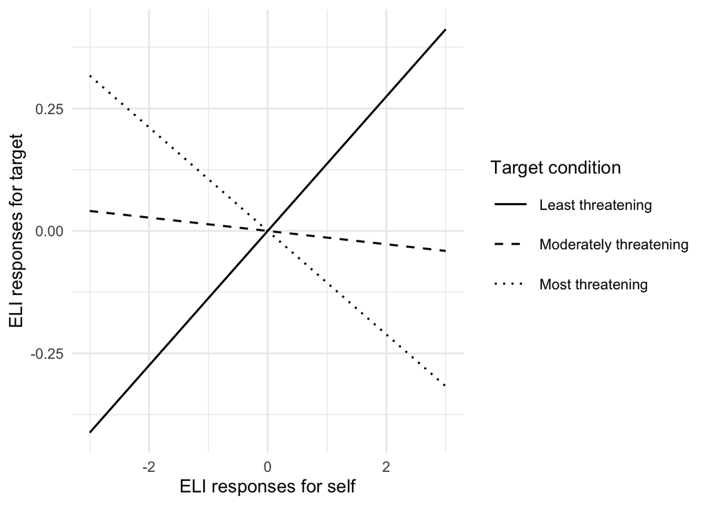

```r
eli_targ_effects <- effect("eli_self_pmc:target_condition",
                         xlevels = list(target_condition = c("CONTROL",
                                                             "WARM",
                                                             "LOSS")),
                         mod = eli_1c)

eli_targ_effects <- as.data.frame(eli_targ_effects)
eli_targ_effects$target_condition <- as.factor(eli_targ_effects$target_condition)

eli_targ_effects %<>%
  mutate(target_condition = as.factor(forcats::fct_relevel(target_condition, c("CONTROL", "WARM", "LOSS"))))


ggplot(eli_targ_effects, aes(eli_self_pmc, fit, group = target_condition)) +
  geom_smooth(method = "lm",
                size = .7,
                se = FALSE,
                colour = "black",
                aes(linetype = target_condition)) +
    theme_minimal(base_size = 13) +
    theme(legend.key.size = unit(1, "cm")) +
  scale_linetype_manual("Target condition",
                        breaks = c("CONTROL", "WARM", "LOSS"),
                       labels = c("Least threatening",
                                  "Moderately threatening",
                                  "Most threatening"),
                       values = c("solid",
                                  "dashed",
                                  "dotted")) +
    labs(x = "ELI responses for self",
       y = "ELI responses for target")
```

## Target condition only - stereotyping

```r
eli_1c_stereo <- lmer(eli_targ_pmc ~ eli_self_pmc*target_condition*eli_stereo_pmc +
                     (0 + eli_self_pmc | sub_id),
                   data = clean_data_eli)

summary(eli_1c_stereo)
```

```
## Linear mixed model fit by REML ['lmerMod']
## Formula: eli_targ_pmc ~ eli_self_pmc * target_condition * eli_stereo_pmc +
##     (0 + eli_self_pmc | sub_id)
##    Data: clean_data_eli
##
## REML criterion at convergence: 11530.1
##
## Scaled residuals:
##     Min      1Q  Median      3Q     Max
## -3.5019 -0.5796  0.0149  0.6431  3.3243
##
## Random effects:
##  Groups   Name         Variance Std.Dev.
##  sub_id   eli_self_pmc 0.02755  0.1660
##  Residual              0.83951  0.9162
## Number of obs: 4240, groups:  sub_id, 424
##
## Fixed effects:
##                                                     Estimate  Std. Error
## (Intercept)                                       0.00004661  0.02358938
## eli_self_pmc                                      0.13475015  0.02323766
## target_conditionLOSS                              0.00088462  0.03482260
## target_conditionWARM                             -0.00004290  0.03369698
## eli_stereo_pmc                                    0.07508770  0.02083289
## eli_self_pmc:target_conditionLOSS                -0.22837933  0.03417099
## eli_self_pmc:target_conditionWARM                -0.14698178  0.03321208
## eli_self_pmc:eli_stereo_pmc                      -0.00102735  0.01548894
## target_conditionLOSS:eli_stereo_pmc               0.48518770  0.03061826
## target_conditionWARM:eli_stereo_pmc               0.19320182  0.02937645
## eli_self_pmc:target_conditionLOSS:eli_stereo_pmc  0.02874757  0.02228949
## eli_self_pmc:target_conditionWARM:eli_stereo_pmc  0.00126749  0.02191875
##                                                  t value
## (Intercept)                                        0.002
## eli_self_pmc                                       5.799
## target_conditionLOSS                               0.025
## target_conditionWARM                              -0.001
## eli_stereo_pmc                                     3.604
## eli_self_pmc:target_conditionLOSS                 -6.683
## eli_self_pmc:target_conditionWARM                 -4.426
## eli_self_pmc:eli_stereo_pmc                       -0.066
```

[output cut: 15 more lines]

```
## trg_WARM:__  0.001  0.018  0.000  -0.001  -0.709 -0.012     -0.012     -0.019
## e__:_LOSS:_  0.021 -0.044 -0.003  -0.014  -0.018  0.042      0.031     -0.695
## e__:_WARM:_  0.021 -0.045 -0.014  -0.010  -0.019  0.031      0.065     -0.707
##             t_LOSS: t_WARM: e__:_LOSS:
## eli_slf_pmc
## trgt_cnLOSS
## trgt_cnWARM
## eli_str_pmc
## el_s_:_LOSS
## el_s_:_WARM
## el_slf_p:__
## trg_LOSS:__
## trg_WARM:__  0.483
## e__:_LOSS:_  0.018   0.013
## e__:_WARM:_  0.013  -0.018   0.491
```

```r
tab_model(eli_1c_stereo)
```

|  | eli_targ_pmc |  |  |
| --- | --- | --- | --- |
| Predictors | Estimates | CI | p |
| (Intercept) | 0.00 | -0.05 – 0.05 | 0.998 |
| eli self pmc | 0.13 | 0.09 – 0.18 | **<0.001** |
| target condition [LOSS] | 0.00 | -0.07 – 0.07 | 0.980 |
| target condition [WARM] | -0.00 | -0.07 – 0.07 | 0.999 |
| eli stereo pmc | 0.08 | 0.03 – 0.12 | **<0.001** |
| eli self pmc * target condition [LOSS] | -0.23 | -0.30 – -0.16 | **<0.001** |
| eli self pmc * target condition [WARM] | -0.15 | -0.21 – -0.08 | **<0.001** |
| eli self pmc * eli stereo pmc | -0.00 | -0.03 – 0.03 | 0.947 |
| target condition [LOSS] * eli stereo pmc | 0.49 | 0.43 – 0.55 | **<0.001** |
| target condition [WARM] * eli stereo pmc | 0.19 | 0.14 – 0.25 | **<0.001** |
| (eli self pmc * target condition [LOSS]) * eli stereo pmc | 0.03 | -0.01 – 0.07 | 0.197 |
| (eli self pmc * target condition [WARM]) * eli stereo pmc | 0.00 | -0.04 – 0.04 | 0.954 |
| Random Effects |  |  |  |
| σ<sup>2</sup> | 0.84 |  |  |
| τ<sub>00</sub> |  |  |  |
| τ<sub>00</sub> |  |  |  |
| τ<sub>11</sub> <sub>sub_id.eli_self_pmc</sub> | 0.03 |  |  |
| ρ<sub>01</sub> |  |  |  |
| ρ<sub>01</sub> |  |  |  |
| ICC | 0.05 |  |  |
| N <sub>sub_id</sub> | 424 |  |  |
| Observations | 4240 |  |  |
| Marginal R<sup>2</sup> / Conditional R<sup>2</sup> | 0.173 / 0.216 |  |  |

### Simple Slopes

```r
eli_targ_stereo_ss <- emtrends(eli_1c_stereo, ~ target_condition,
                              var ="eli_self_pmc",
                              at = list(target_condition = c("CONTROL",
                                                             "LOSS",
                                                             "WARM")))

eli_targ_stereo_ss
```

```
##  target_condition eli_self_pmc.trend     SE  df asymp.LCL asymp.UCL
##  CONTROL                      0.1348 0.0232 Inf    0.0892    0.1803
##  LOSS                        -0.0936 0.0251 Inf   -0.1427   -0.0445
##  WARM                        -0.0122 0.0237 Inf   -0.0587    0.0343
##
## Degrees-of-freedom method: asymptotic
## Confidence level used: 0.95
```

### Visualization

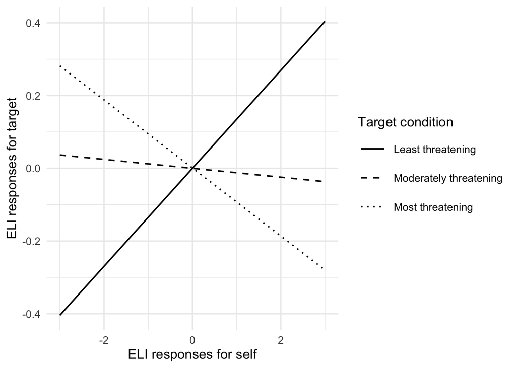

```r
eli_targ_effects_stereo <- effect("eli_self_pmc:target_condition",
                         xlevels = list(target_condition = c("CONTROL",
                                                             "WARM",
                                                             "LOSS")),
                         mod = eli_1c_stereo)

eli_targ_effects_stereo <- as.data.frame(eli_targ_effects_stereo)
eli_targ_effects_stereo$target_condition <- as.factor(eli_targ_effects_stereo$target_condition)

eli_targ_effects_stereo %<>%
  mutate(target_condition = as.factor(forcats::fct_relevel(target_condition, c("CONTROL", "WARM", "LOSS"))))


ggplot(eli_targ_effects_stereo, aes(eli_self_pmc, fit, group = target_condition)) +
  geom_smooth(method = "lm",
                size = .7,
                se = FALSE,
                colour = "black",
                aes(linetype = target_condition)) +
    theme_minimal(base_size = 13) +
    theme(legend.key.size = unit(1, "cm")) +
  scale_linetype_manual("Target condition",
                        breaks = c("CONTROL", "WARM", "LOSS"),
                       labels = c("Least threatening",
                                  "Moderately threatening",
                                  "Most threatening"),
                       values = c("solid",
                                  "dashed",
                                  "dotted")) +
    labs(x = "ELI responses for self",
       y = "ELI responses for target")
```

## Condition and threat

```r
model1b_eli_randslopes <- lmer(eli_targ_pmc ~ eli_self_pmc*itt_comp_gmc*target_condition +
                     (0 + eli_self_pmc | sub_id),
                   data = clean_data_eli) # Model only works with the whole data-set (clean_data), not when filtered down to only include observations (thus none repeated) for this analysis with mod_1_data_bfi

tab_model(model1b_eli_randslopes,
          digits = 3)
```

|  | eli_targ_pmc |  |  |
| --- | --- | --- | --- |
| Predictors | Estimates | CI | p |
| (Intercept) | 0.000 | -0.082 – 0.082 | 1.000 |
| eli self pmc | 0.088 | 0.009 – 0.168 | **0.029** |
| itt comp gmc | 0.000 | -0.065 – 0.065 | 1.000 |
| target condition [LOSS] | -0.000 | -0.112 – 0.112 | 1.000 |
| target condition [WARM] | 0.000 | -0.100 – 0.100 | 1.000 |
| eli self pmc * itt comp gmc | -0.050 | -0.113 – 0.013 | 0.122 |
| eli self pmc * target condition [LOSS] | -0.119 | -0.230 – -0.008 | **0.036** |
| eli self pmc * target condition [WARM] | -0.104 | -0.202 – -0.006 | **0.038** |
| itt comp gmc * target condition [LOSS] | 0.000 | -0.102 – 0.102 | 1.000 |
| itt comp gmc * target condition [WARM] | 0.000 | -0.091 – 0.091 | 1.000 |
| (eli self pmc * itt comp gmc) * target condition [LOSS] | -0.054 | -0.153 – 0.046 | 0.291 |
| (eli self pmc * itt comp gmc) * target condition [WARM] | 0.054 | -0.035 – 0.144 | 0.237 |
| Random Effects |  |  |  |
| σ<sup>2</sup> | 1.00 |  |  |
| τ<sub>00</sub> |  |  |  |
| τ<sub>00</sub> |  |  |  |
| τ<sub>11</sub> <sub>sub_id.eli_self_pmc</sub> | 0.03 |  |  |
| ρ<sub>01</sub> |  |  |  |
| ρ<sub>01</sub> |  |  |  |
| ICC | 0.05 |  |  |
| N <sub>sub_id</sub> | 424 |  |  |
| Observations | 4240 |  |  |
| Marginal R<sup>2</sup> / Conditional R<sup>2</sup> | 0.019 / 0.072 |  |  |

Similiar to the BFI, but no interaction.

### Simple slopes

```r
eli_targ_comp_simpslopes <- emtrends(model1b_eli_randslopes, ~ itt_comp_gmc*target_condition,
                              var = "eli_self_pmc",
                              at = list(target_condition = c("CONTROL",
                                                             "LOSS",
                                                             "WARM"),
                                        itt_comp_gmc = c(-1.07, 0.0, 1.07)))

eli_targ_comp_simpslopes
```

```
##  itt_comp_gmc target_condition eli_self_pmc.trend     SE  df asymp.LCL
##         -1.07 CONTROL                      0.1418 0.0256 Inf   0.09158
##          0.00 CONTROL                      0.0885 0.0405 Inf   0.00909
##          1.07 CONTROL                      0.0351 0.0708 Inf  -0.10354
##         -1.07 LOSS                         0.0804 0.0755 Inf  -0.06760
##          0.00 LOSS                        -0.0302 0.0396 Inf  -0.10786
##          1.07 LOSS                        -0.1409 0.0306 Inf  -0.20078
##         -1.07 WARM                        -0.0200 0.0548 Inf  -0.12736
##          0.00 WARM                        -0.0155 0.0294 Inf  -0.07311
##          1.07 WARM                        -0.0111 0.0334 Inf  -0.07645
##  asymp.UCL
##     0.1921
##     0.1679
##     0.1738
##     0.2284
##     0.0474
##    -0.0809
##     0.0874
##     0.0420
##     0.0543
##
## Degrees-of-freedom method: asymptotic
## Confidence level used: 0.95
```

### Visualization

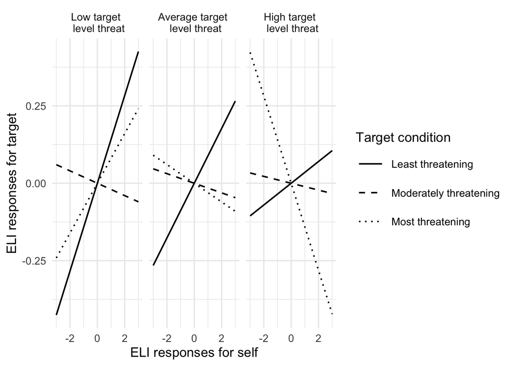

```r
eli_targ_cond_int_effects <- effect("eli_self_pmc:itt_comp_gmc:target_condition",
                         xlevels = list(itt_comp_gmc = c(-1.07, 0.0, 1.07),
                                        target_condition = c("CONTROL",
                                                             "WARM",
                                                             "LOSS")),
                         mod = model1b_eli_randslopes)

eli_targ_cond_int_effects <- as.data.frame(eli_targ_cond_int_effects)
eli_targ_cond_int_effects$itt_comp_gmc <- as.factor(eli_targ_cond_int_effects$itt_comp_gmc)
eli_targ_cond_int_effects$target_condition <- as.factor(eli_targ_cond_int_effects$target_condition)

threat_labels <- c("-1.07" = "Low target \n level threat",
                   "0" = "Average target \n level threat",
                   "1.07" = "High target \n level threat")

ggplot(eli_targ_cond_int_effects, aes(eli_self_pmc, fit, group = target_condition)) +
  geom_smooth(method = "lm",
                size = .7,
                se = FALSE,
                colour = "black",
                aes(linetype = target_condition)) +
    theme_minimal(base_size = 13) +
    theme(legend.key.size = unit(1, "cm")) +
  facet_wrap(~itt_comp_gmc,
             labeller = labeller(itt_comp_gmc = threat_labels)) +
  scale_linetype_manual("Target condition",
                        breaks = c("CONTROL", "WARM", "LOSS"),
                       labels = c("Least threatening",
                                  "Moderately threatening",
                                  "Most threatening"),
                       values = c("solid",
                                  "dashed",
                                  "dotted")) +
    labs(
       x = "ELI responses for self",
       y = "ELI responses for target")
```

## Condition and threat - stereotyping

```r
model1b_eli_randslopes_stereo <- lmer(eli_targ_pmc ~ eli_self_pmc*itt_comp_gmc*target_condition*eli_stereo_pmc +
                     (0 + eli_self_pmc | sub_id),
                   data = clean_data_eli) # Model only works with the whole data-set (clean_data), not when filtered down to only include observations (thus none repeated) for this analysis with mod_1_data_bfi

tab_model(model1b_eli_randslopes_stereo,
          digits = 3)
```

|  | eli_targ_pmc |  |  |
| --- | --- | --- | --- |
| Predictors | Estimates | CI | p |
| (Intercept) | 0.002 | -0.073 – 0.077 | 0.959 |
| eli self pmc | 0.096 | 0.024 – 0.169 | **0.009** |
| itt comp gmc | 0.001 | -0.058 – 0.060 | 0.976 |
| target condition [LOSS] | -0.006 | -0.111 – 0.099 | 0.910 |
| target condition [WARM] | -0.001 | -0.093 – 0.091 | 0.984 |
| eli stereo pmc | 0.131 | 0.068 – 0.193 | **<0.001** |
| eli self pmc * itt comp gmc | -0.042 | -0.099 – 0.016 | 0.157 |
| eli self pmc * target condition [LOSS] | -0.159 | -0.262 – -0.056 | **0.002** |
| eli self pmc * target condition [WARM] | -0.114 | -0.203 – -0.024 | **0.013** |
| itt comp gmc * target condition [LOSS] | 0.007 | -0.088 – 0.101 | 0.891 |
| itt comp gmc * target condition [WARM] | -0.002 | -0.085 – 0.081 | 0.966 |
| eli self pmc * eli stereo pmc | 0.012 | -0.035 – 0.059 | 0.611 |
| itt comp gmc * eli stereo pmc | 0.062 | 0.011 – 0.113 | **0.017** |
| target condition [LOSS] * eli stereo pmc | 0.343 | 0.247 – 0.438 | **<0.001** |
| target condition [WARM] * eli stereo pmc | 0.115 | 0.036 – 0.194 | **0.004** |
| (eli self pmc * itt comp gmc) * target condition [LOSS] | 0.010 | -0.081 – 0.102 | 0.824 |
| (eli self pmc * itt comp gmc) * target condition [WARM] | 0.057 | -0.025 – 0.138 | 0.174 |
| (eli self pmc * itt comp gmc) * eli stereo pmc | 0.017 | -0.020 – 0.055 | 0.368 |
| (eli self pmc * target condition [LOSS]) * eli stereo pmc | 0.013 | -0.057 – 0.083 | 0.709 |
| (eli self pmc * target condition [WARM]) * eli stereo pmc | -0.021 | -0.080 – 0.037 | 0.478 |
| (itt comp gmc * target condition [LOSS]) * eli stereo pmc | 0.044 | -0.043 – 0.131 | 0.319 |
| (itt comp gmc * target condition [WARM]) * eli stereo pmc | -0.020 | -0.090 – 0.051 | 0.588 |
| (eli self pmc * itt comp gmc * target condition [LOSS]) * eli stereo pmc | -0.015 | -0.076 – 0.046 | 0.628 |
| (eli self pmc * itt comp gmc * target condition [WARM]) * eli stereo pmc | 0.001 | -0.052 – 0.054 | 0.970 |
| Random Effects |  |  |  |
| σ<sup>2</sup> | 0.84 |  |  |
| τ<sub>00</sub> |  |  |  |
| τ<sub>00</sub> |  |  |  |
| τ<sub>11</sub> <sub>sub_id.eli_self_pmc</sub> | 0.03 |  |  |
| ρ<sub>01</sub> |  |  |  |
| ρ<sub>01</sub> |  |  |  |
| ICC | 0.05 |  |  |
| N <sub>sub_id</sub> | 424 |  |  |
| Observations | 4240 |  |  |
| Marginal R<sup>2</sup> / Conditional R<sup>2</sup> | 0.178 / 0.220 |  |  |

### Simple slopes

```r
eli_targ_comp_simpslopes_stereo <- emtrends(model1b_eli_randslopes_stereo, ~ itt_comp_gmc*target_condition,
                              var = "eli_self_pmc",
                              at = list(target_condition = c("CONTROL",
                                                             "LOSS",
                                                             "WARM"),
                                        itt_comp_gmc = c(-1.07, 0.0, 1.07)))

eli_targ_comp_simpslopes_stereo
```

```
##  itt_comp_gmc target_condition eli_self_pmc.trend     SE  df asymp.LCL
##         -1.07 CONTROL                     0.14093 0.0233 Inf    0.0952
##          0.00 CONTROL                     0.09635 0.0370 Inf    0.0238
##          1.07 CONTROL                     0.05177 0.0647 Inf   -0.0749
##         -1.07 LOSS                       -0.02912 0.0709 Inf   -0.1681
##          0.00 LOSS                       -0.06253 0.0371 Inf   -0.1353
##          1.07 LOSS                       -0.09594 0.0278 Inf   -0.1505
##         -1.07 WARM                       -0.03330 0.0499 Inf   -0.1312
##          0.00 WARM                       -0.01731 0.0267 Inf   -0.0697
##          1.07 WARM                       -0.00132 0.0304 Inf   -0.0609
##  asymp.UCL
##     0.1867
##     0.1689
##     0.1785
##     0.1099
##     0.0102
##    -0.0414
##     0.0646
##     0.0351
##     0.0583
##
## Degrees-of-freedom method: asymptotic
## Confidence level used: 0.95
```

### Visualization

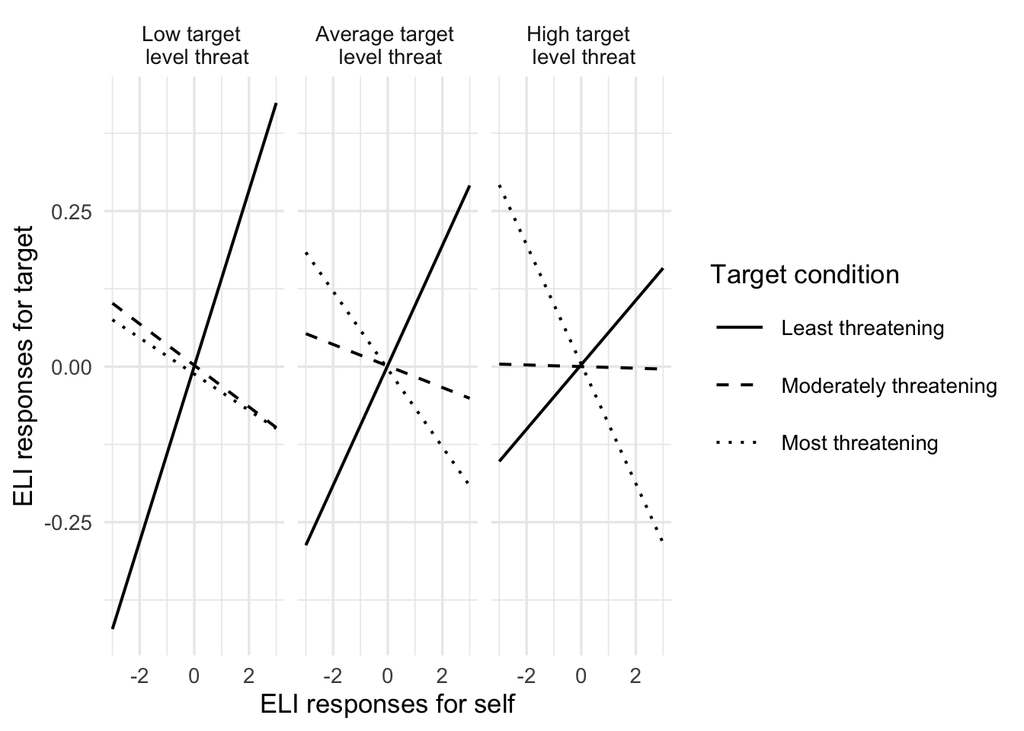

```r
eli_targ_cond_int_effects_stereo <- effect("eli_self_pmc:itt_comp_gmc:target_condition",
                         xlevels = list(itt_comp_gmc = c(-1.07, 0.0, 1.07),
                                        target_condition = c("CONTROL",
                                                             "WARM",
                                                             "LOSS")),
                         mod = model1b_eli_randslopes_stereo)

eli_targ_cond_int_effects_stereo <- as.data.frame(eli_targ_cond_int_effects_stereo)
eli_targ_cond_int_effects_stereo$itt_comp_gmc <- as.factor(eli_targ_cond_int_effects_stereo$itt_comp_gmc)
eli_targ_cond_int_effects_stereo$target_condition <- as.factor(eli_targ_cond_int_effects_stereo$target_condition)

threat_labels <- c("-1.07" = "Low target \n level threat",
                   "0" = "Average target \n level threat",
                   "1.07" = "High target \n level threat")

ggplot(eli_targ_cond_int_effects_stereo, aes(eli_self_pmc, fit, group = target_condition)) +
  geom_smooth(method = "lm",
                size = .7,
                se = FALSE,
                colour = "black",
                aes(linetype = target_condition)) +
    theme_minimal(base_size = 13) +
    theme(legend.key.size = unit(1, "cm")) +
  facet_wrap(~itt_comp_gmc,
             labeller = labeller(itt_comp_gmc = threat_labels)) +
  scale_linetype_manual("Target condition",
                        breaks = c("CONTROL", "WARM", "LOSS"),
                       labels = c("Least threatening",
                                  "Moderately threatening",
                                  "Most threatening"),
                       values = c("solid",
                                  "dashed",
                                  "dotted")) +
    labs(
       x = "ELI responses for self",
       y = "ELI responses for target")
```